# Telecommunication Customer Churn Prediction

# In this notebook we will:

- Show and introduce our data.
- Clean Data.
- Analyze data to get best features to use in churn prediction.
- Build ML Model.

# Data Wrangling

#### Load our data

|  | State | Account Length | Area Code | Phone | Int'l Plan | VMail Plan | VMail Message | Day Mins | Day Calls | Day Charge | ... | Eve Calls | Eve Charge | Night Mins | Night Calls | Night Charge | Intl Mins | Intl Calls | Intl Charge | CustServ Calls | Churn? |
| --- | --- | --- | --- | --- | --- | --- | --- | --- | --- | --- | --- | --- | --- | --- | --- | --- | --- | --- | --- | --- | --- |
| 0 | PA | 163 | 806 | 403-2562 | no | yes | 300 | 8.162204 | 3 | 7.579174 | ... | 4 | 6.508639 | 4.065759 | 100 | 5.111624 | 4.928160 | 6 | 5.673203 | 3 | True. |
| 1 | SC | 15 | 836 | 158-8416 | yes | no | 0 | 10.018993 | 4 | 4.226289 | ... | 0 | 9.972592 | 7.141040 | 200 | 6.436188 | 3.221748 | 6 | 2.559749 | 8 | False. |
| 2 | MO | 131 | 777 | 896-6253 | no | yes | 300 | 4.708490 | 3 | 4.768160 | ... | 3 | 4.566715 | 5.363235 | 100 | 5.142451 | 7.139023 | 2 | 6.254157 | 4 | False. |
| 3 | WY | 75 | 878 | 817-5729 | yes | yes | 700 | 1.268734 | 3 | 2.567642 | ... | 5 | 2.333624 | 3.773586 | 450 | 3.814413 | 2.245779 | 6 | 1.080692 | 6 | False. |
| 4 | WY | 146 | 878 | 450-4942 | yes | no | 0 | 2.696177 | 3 | 5.908916 | ... | 3 | 3.670408 | 3.751673 | 250 | 2.796812 | 6.905545 | 4 | 7.134343 | 6 | True. |

5 rows × 21 columns

#### Number of rows and columns

```
(5000, 21)
```

#### Data Information

```
<class 'pandas.core.frame.DataFrame'>
RangeIndex: 5000 entries, 0 to 4999
Data columns (total 21 columns):
 #   Column          Non-Null Count  Dtype
---  ------          --------------  -----
 0   State           5000 non-null   object
 1   Account Length  5000 non-null   int64
 2   Area Code       5000 non-null   int64
 3   Phone           5000 non-null   object
 4   Int'l Plan      5000 non-null   object
 5   VMail Plan      5000 non-null   object
 6   VMail Message   5000 non-null   int64
 7   Day Mins        5000 non-null   float64
 8   Day Calls       5000 non-null   int64
 9   Day Charge      5000 non-null   float64
 10  Eve Mins        5000 non-null   float64
 11  Eve Calls       5000 non-null   int64
 12  Eve Charge      5000 non-null   float64
 13  Night Mins      5000 non-null   float64
 14  Night Calls     5000 non-null   int64
 15  Night Charge    5000 non-null   float64
 16  Intl Mins       5000 non-null   float64
 17  Intl Calls      5000 non-null   int64
 18  Intl Charge     5000 non-null   float64
 19  CustServ Calls  5000 non-null   int64
 20  Churn?          5000 non-null   object
dtypes: float64(8), int64(8), object(5)
memory usage: 820.4+ KB
```

#### check null values

```
State             0
Account Length    0
Area Code         0
Phone             0
Int'l Plan        0
VMail Plan        0
VMail Message     0
Day Mins          0
Day Calls         0
Day Charge        0
Eve Mins          0
Eve Calls         0
Eve Charge        0
Night Mins        0
Night Calls       0
Night Charge      0
Intl Mins         0
Intl Calls        0
Intl Charge       0
CustServ Calls    0
Churn?            0
dtype: int64
```

##### Summary Statistics

|  | Account Length | Area Code | VMail Message | Day Mins | Day Calls | Day Charge | Eve Mins | Eve Calls | Eve Charge | Night Mins | Night Calls | Night Charge | Intl Mins | Intl Calls | Intl Charge | CustServ Calls |
| --- | --- | --- | --- | --- | --- | --- | --- | --- | --- | --- | --- | --- | --- | --- | --- | --- |
| count | 5000.000000 | 5000.000000 | 5000.000000 | 5000.000000 | 5000.00000 | 5000.000000 | 5000.000000 | 5000.000000 | 5000.000000 | 5000.000000 | 5000.000000 | 5000.000000 | 5000.000000 | 5000.000000 | 5000.000000 | 5000.000000 |
| mean | 101.675800 | 773.791400 | 226.680000 | 5.518757 | 3.50460 | 5.018902 | 5.026199 | 3.140400 | 5.017557 | 4.000917 | 224.790000 | 5.023490 | 5.025876 | 5.475400 | 4.328242 | 5.525800 |
| std | 57.596762 | 63.470888 | 273.998527 | 3.433485 | 1.68812 | 2.195759 | 2.135487 | 2.525621 | 2.127857 | 1.631001 | 97.302875 | 1.748900 | 1.019302 | 1.877045 | 2.440311 | 2.041217 |
| min | 1.000000 | 657.000000 | 0.000000 | 0.000215 | 0.00000 | 0.004777 | 0.004659 | 0.000000 | 0.013573 | 0.008468 | 0.000000 | 0.054863 | 1.648514 | 0.000000 | 0.000769 | 0.000000 |
| 25% | 52.000000 | 736.000000 | 0.000000 | 2.682384 | 2.00000 | 3.470151 | 3.588466 | 1.000000 | 3.529613 | 2.921998 | 150.000000 | 3.873157 | 4.349726 | 4.000000 | 2.468225 | 4.000000 |
| 50% | 102.000000 | 778.000000 | 0.000000 | 5.336245 | 3.00000 | 4.988291 | 5.145656 | 3.000000 | 5.006860 | 3.962089 | 200.000000 | 5.169154 | 5.034905 | 5.000000 | 4.214058 | 6.000000 |
| 75% | 151.000000 | 806.000000 | 400.000000 | 7.936151 | 5.00000 | 6.559750 | 6.552962 | 5.000000 | 6.491725 | 5.100128 | 300.000000 | 6.272015 | 5.716386 | 7.000000 | 5.960654 | 7.000000 |
| max | 200.000000 | 878.000000 | 1300.000000 | 16.897529 | 10.00000 | 12.731936 | 13.622097 | 14.000000 | 12.352871 | 10.183378 | 550.000000 | 10.407778 | 8.405644 | 12.000000 | 14.212261 | 13.000000 |

#### Chek number of unique values for each features

```
VMail_Message 0.28
Day_Calls 0.22
Eve_Calls 0.3
Night_Calls 0.24
Intl_Calls 0.26
CustServ_Calls 0.28
```

# Analyze "Churn" Column (the target)

```
Total Churn rate is : 49.96%
```

##### Churn rate for every state

| State | NY | OH | AZ | MD | CT | NE | IA | NC | AK | ME | MS | MI | KS | OR | WV | KY | PA | SC | UT | ID | MT | TX | CA | MO | DC | WY | HI | DE | RI | … |
| --- | --- | --- | --- | --- | --- | --- | --- | --- | --- | --- | --- | --- | --- | --- | --- | --- | --- | --- | --- | --- | --- | --- | --- | --- | --- | --- | --- | --- | --- | --- |
| churn_rate | 61.22449 | 56.756757 | 56.666667 | 56.637168 | 56.179775 | 55.963303 | 55.339806 | 54.736842 | 54.117647 | 54.054054 | 53.773585 | 53.465347 | 53.164557 | 52.941176 | 52.884615 | 52.747253 | 52.525253 | 52.212389 | 51.578947 | 51.351351 | 51.111111 | 51.020408 | 50.961538 | 50.943396 | 50.0 | 49.514563 | 49.473684 | 49.450549 | 49.166667 | … |

#### show summary statistics

|  | count | mean | std | min | 25% | 50% | 75% | max |
| --- | --- | --- | --- | --- | --- | --- | --- | --- |
| churn_rate | 51.0 | 49.902132 | 4.50616 | 41.414141 | 46.357323 | 49.514563 | 53.052867 | 61.22449 |

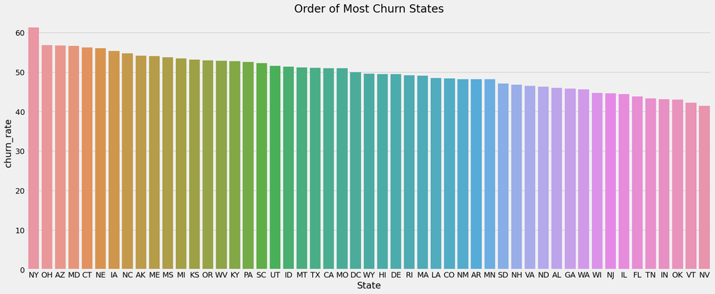

*NY State Has The Largest Churn Rate 61.2%*

### Check outliers in Data Frame

```
We use the input dataframe as is...
```

|  | Data Type | Missing Values% | Unique Values% | Minimum Value | Maximum Value | DQ Issue |
| --- | --- | --- | --- | --- | --- | --- |
| Churn | bool | 0.000000 | 0 | False | True | No issue |
| State | object | 0.000000 | 1 | AK | WY | 51 rare categories: Too many to list. Group them into a single category or drop the categories. |
| Account_Length | int64 | 0.000000 | 4 | 1 | 200 | No issue |
| Area_Code | object | 0.000000 | 0 | 657 | 878 | 29 rare categories: Too many to list. Group them into a single category or drop the categories. |
| Phone | object | 0.000000 | 99 | 100-2030 | 999-9817 | 4999 rare categories: Too many to list. Group them into a single category or drop the categories., high cardinality with 4999 unique values: Use hash encoding or embedding to reduce dimension. |
| Int'l_Plan | bool | 0.000000 | 0 | False | True | No issue |
| VMail_Plan | bool | 0.000000 | 0 | False | True | No issue |
| VMail_Message | int64 | 0.000000 | 0 | 0 | 1300 | has 11 outliers greater than upper bound (1000.0) or lower than lower bound(-600.0). Cap them or remove them., has a high correlation with ['VMail_Plan']. Consider dropping one of them. |
| Day_Mins | float64 | 0.000000 | NA | 0.000215 | 16.897529 | has 9 outliers greater than upper bound (15.816801533731176) or lower than lower bound(-5.198265919447645). Cap them or remove them. |
| Day_Calls | int64 | 0.000000 | 0 | 0 | 10 | has 2 outliers greater than upper bound (9.5) or lower than lower bound(-2.5). Cap them or remove them. |
| Day_Charge | float64 | 0.000000 | NA | 0.004777 | 12.731936 | has 8 outliers greater than upper bound (11.194148388880489) or lower than lower bound(-1.16424745993953). Cap them or remove them. |
| Eve_Mins | float64 | 0.000000 | NA | 0.004659 | 13.622097 | has 7 outliers greater than upper bound (10.99970516769563) or lower than lower bound(-0.8582779312233817). Cap them or remove them. |
| Eve_Calls | int64 | 0.000000 | 0 | 0 | 14 | has 13 outliers greater than upper bound (11.0) or lower than lower bound(-5.0). Cap them or remove them. |
| Eve_Charge | float64 | 0.000000 | NA | 0.013573 | 12.352871 | has 10 outliers greater than upper bound (10.93489164532276) or lower than lower bound(-0.9135534910162573). Cap them or remove them. |
| Night_Mins | float64 | 0.000000 | NA | 0.008468 | 10.183378 | has 25 outliers greater than upper bound (8.367323690877539) or lower than lower bound(-0.34519816553823324). Cap them or remove them. |
| Night_Calls | int64 | 0.000000 | 0 | 0 | 550 | has 5 outliers greater than upper bound (525.0) or lower than lower bound(-75.0). Cap them or remove them. |
| Night_Charge | float64 | 0.000000 | NA | 0.054863 | 10.407778 | has 16 outliers greater than upper bound (9.870301404833606) or lower than lower bound(0.27487054266300026). Cap them or remove them. |
| Intl_Mins | float64 | 0.000000 | NA | 1.648514 | 8.405644 | has 35 outliers greater than upper bound (7.766374716492607) or lower than lower bound(2.299737088494262). Cap them or remove them. |
| Intl_Calls | int64 | 0.000000 | 0 | 0 | 12 | has 2 outliers greater than upper bound (11.5) or lower than lower bound(-0.5). Cap them or remove them. |
| Intl_Charge | float64 | 0.000000 | NA | 0.000769 | 14.212261 | has 24 outliers greater than upper bound (11.19929718300197) or lower than lower bound(-2.770418271102039). Cap them or remove them. |
| CustServ_Calls | int64 | 0.000000 | 0 | 0 | 13 | has 13 outliers greater than upper bound (11.5) or lower than lower bound(-0.5). Cap them or remove them. |

### Scatter plot between Churn and other Features

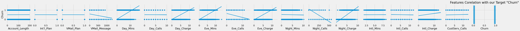

#### Let's Check Features corelation with Each Other

|  | Churn | Account_Length | Int'l_Plan | VMail_Plan | VMail_Message | Day_Mins | Day_Calls | Day_Charge | Eve_Mins | Eve_Calls | Eve_Charge | Night_Mins | Night_Calls | Night_Charge | Intl_Mins | Intl_Calls | Intl_Charge | CustServ_Calls |
| --- | --- | --- | --- | --- | --- | --- | --- | --- | --- | --- | --- | --- | --- | --- | --- | --- | --- | --- |
| Churn | 1.00 | 0.00 | -0.00 | -0.00 | -0.19 | 0.58 | -0.00 | 0.44 | 0.43 | -0.22 | 0.46 | -0.02 | -0.51 | 0.57 | 0.00 | -0.01 | 0.11 | 0.02 |
| Day_Mins | 0.58 | -0.02 | -0.00 | 0.00 | -0.14 | 1.00 | -0.09 | 0.67 | 0.48 | -0.18 | 0.77 | 0.19 | -0.45 | 0.57 | 0.00 | 0.24 | 0.24 | -0.20 |
| Night_Charge | 0.57 | -0.03 | -0.01 | 0.01 | -0.16 | 0.57 | 0.05 | 0.37 | 0.32 | -0.32 | 0.55 | -0.14 | -0.39 | 1.00 | 0.01 | -0.01 | -0.33 | 0.44 |
| Night_Calls | -0.51 | -0.00 | -0.02 | -0.00 | 0.14 | -0.45 | -0.08 | -0.13 | 0.07 | 0.22 | -0.45 | -0.22 | 1.00 | -0.39 | -0.01 | 0.18 | -0.16 | 0.11 |
| Eve_Charge | 0.46 | -0.01 | 0.01 | 0.00 | -0.03 | 0.77 | -0.05 | 0.37 | 0.27 | -0.47 | 1.00 | 0.18 | -0.45 | 0.55 | -0.00 | 0.16 | 0.24 | -0.01 |
| Day_Charge | 0.44 | -0.01 | -0.01 | 0.01 | -0.18 | 0.67 | -0.22 | 1.00 | 0.57 | 0.24 | 0.37 | 0.15 | -0.13 | 0.37 | 0.01 | 0.12 | 0.25 | -0.26 |
| Eve_Mins | 0.43 | 0.00 | -0.00 | -0.00 | -0.10 | 0.48 | 0.03 | 0.57 | 1.00 | -0.07 | 0.27 | -0.09 | 0.07 | 0.32 | -0.02 | 0.07 | 0.45 | -0.17 |
| Eve_Calls | -0.22 | 0.03 | -0.03 | -0.01 | -0.10 | -0.18 | 0.19 | 0.24 | -0.07 | 1.00 | -0.47 | 0.22 | 0.22 | -0.32 | -0.00 | -0.11 | 0.02 | -0.43 |
| VMail_Message | -0.19 | -0.01 | 0.02 | 0.82 | 1.00 | -0.14 | 0.00 | -0.18 | -0.10 | -0.10 | -0.03 | 0.06 | 0.14 | -0.16 | -0.02 | 0.13 | 0.01 | 0.07 |
| Intl_Charge | 0.11 | 0.03 | 0.03 | -0.01 | 0.01 | 0.24 | -0.12 | 0.25 | 0.45 | 0.02 | 0.24 | 0.27 | -0.16 | -0.33 | -0.01 | -0.23 | 1.00 | -0.66 |
| Night_Mins | -0.02 | 0.02 | 0.01 | -0.00 | 0.06 | 0.19 | -0.09 | 0.15 | -0.09 | 0.22 | 0.18 | 1.00 | -0.22 | -0.14 | -0.01 | 0.04 | 0.27 | -0.33 |
| CustServ_Calls | 0.02 | -0.04 | -0.01 | 0.02 | 0.07 | -0.20 | -0.07 | -0.26 | -0.17 | -0.43 | -0.01 | -0.33 | 0.11 | 0.44 | -0.01 | -0.01 | -0.66 | 1.00 |
| Intl_Calls | -0.01 | -0.00 | -0.01 | 0.01 | 0.13 | 0.24 | -0.05 | 0.12 | 0.07 | -0.11 | 0.16 | 0.04 | 0.18 | -0.01 | -0.01 | 1.00 | -0.23 | -0.01 |
| Day_Calls | -0.00 | 0.01 | -0.02 | 0.01 | 0.00 | -0.09 | 1.00 | -0.22 | 0.03 | 0.19 | -0.05 | -0.09 | -0.08 | 0.05 | -0.02 | -0.05 | -0.12 | -0.07 |
| Account_Length | 0.00 | 1.00 | -0.00 | -0.00 | -0.01 | -0.02 | 0.01 | -0.01 | 0.00 | 0.03 | -0.01 | 0.02 | -0.00 | -0.03 | 0.02 | -0.00 | 0.03 | -0.04 |
| VMail_Plan | -0.00 | -0.00 | 0.00 | 1.00 | 0.82 | 0.00 | 0.01 | 0.01 | -0.00 | -0.01 | 0.00 | -0.00 | -0.00 | 0.01 | -0.01 | 0.01 | -0.01 | 0.02 |
| Int'l_Plan | -0.00 | -0.00 | 1.00 | 0.00 | 0.02 | -0.00 | -0.02 | -0.01 | -0.00 | -0.03 | 0.01 | 0.01 | -0.02 | -0.01 | -0.01 | -0.01 | 0.03 | -0.01 |
| Intl_Mins | 0.00 | 0.02 | -0.01 | -0.01 | -0.02 | 0.00 | -0.02 | 0.01 | -0.02 | -0.00 | -0.00 | -0.01 | -0.01 | 0.01 | 1.00 | -0.01 | -0.01 | -0.01 |

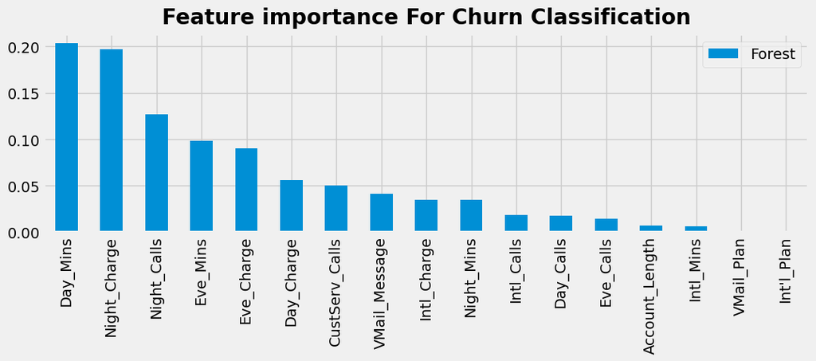

*Concolusion:*

- Churn Has a positive correlation with ["Day_Mins", "Night_Charge", "Eve_Charge", "Day_Charge", "Eve_Mins", "Intl_Charge"]
- Churn Has a negative correlation with ["Night_Calls", "Eve_Calls", "VMail_Message"]
- Other Features Have Weak Correlation with our target.
- *We Can drop 'Eve_Charge' and 'Day_Charge' from our model as they show strong correlation with 'Day_Mins'*

# Analyze Candidate Features

### Analyze Day Mins

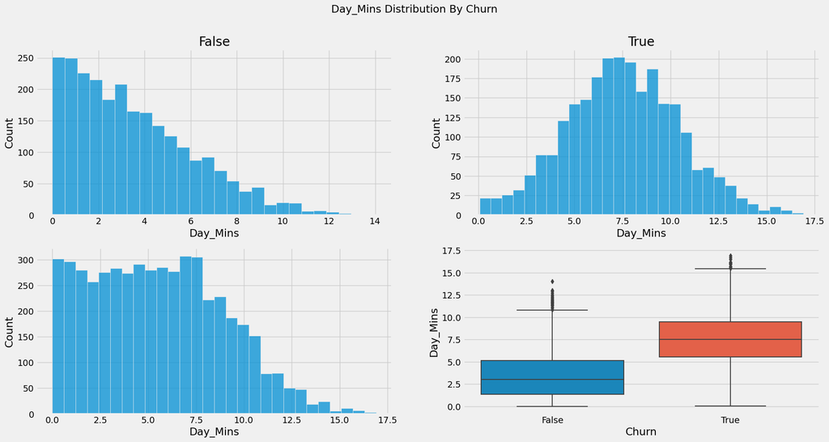

### Analyze Night_Charge

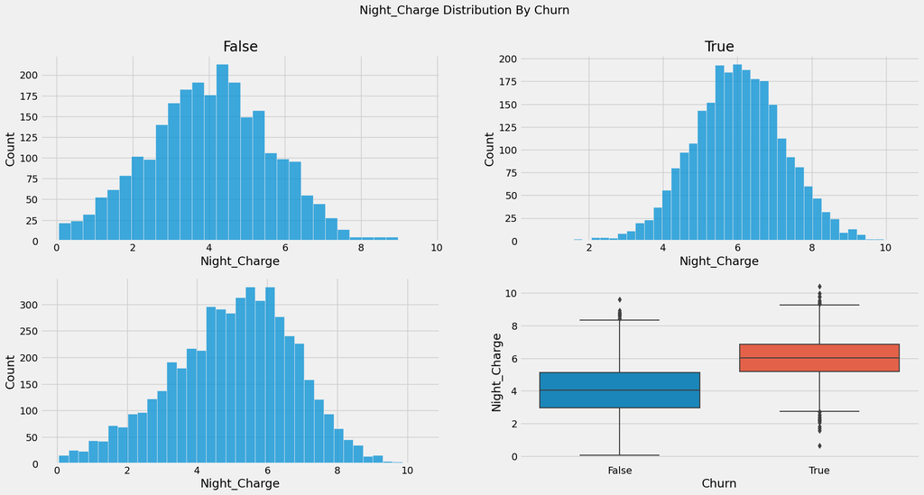

### Analyze Eve Mins

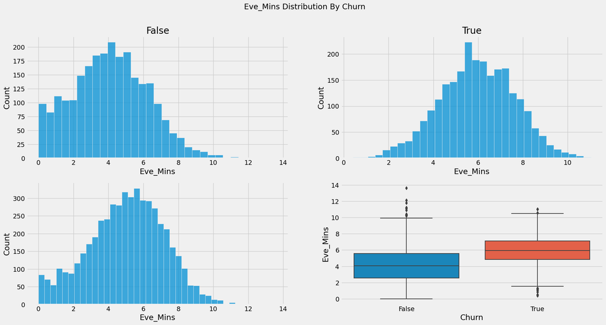

*Churn Customers seems to have long calls in evening with average 6 mins*

### Analyze Night Calls

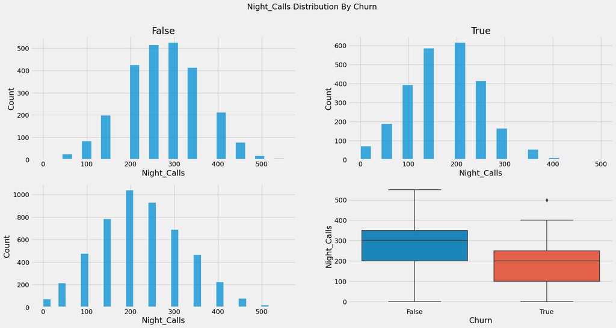

#### Analyze CustServ_Calls

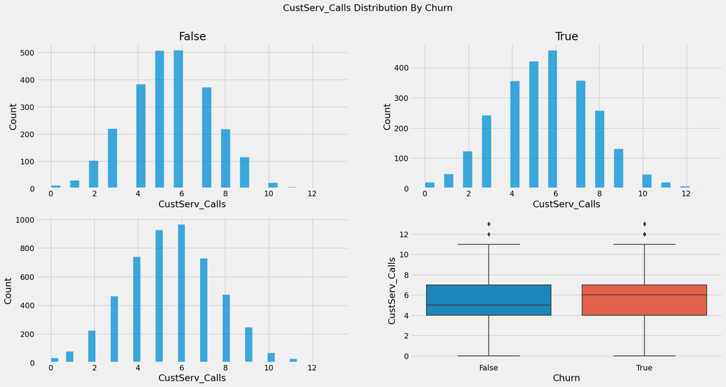

##### Remove OutLiers

```
Day_Mins Feature Has 9 Outliers
Night_Charge Feature Has 16 Outliers
Night_Calls Feature Has 5 Outliers
Eve_Charge Feature Has 10 Outliers
Day_Charge Feature Has 8 Outliers
Eve_Mins Feature Has 7 Outliers
Eve_Calls Feature Has 13 Outliers
VMail_Message Feature Has 11 Outliers
Intl_Charge Feature Has 24 Outliers
Night_Mins Feature Has 25 Outliers
CustServ_Calls Feature Has 13 Outliers
Intl_Calls Feature Has 2 Outliers
Day_Calls Feature Has 2 Outliers
Account_Length Feature Has 0 Outliers
Intl_Mins Feature Has 35 Outliers
================================================================================
NO of Changed Rows Is: 180, New Data Shape Is: (5000, 21)
```

### Train models to choose the best one to continue with

```
LogisticRegression()
New X Shape is  (5000, 11)
Selected Features are :  ['Day_Mins' 'Night_Charge' 'Eve_Charge' 'Day_Charge' 'Eve_Mins'
 'Eve_Calls' 'Intl_Charge' 'Night_Mins' 'CustServ_Calls' 'Intl_Mins'
 'Day_Calls']
```

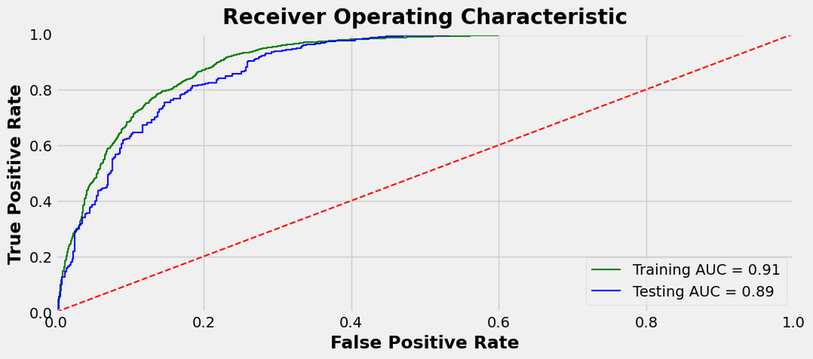

```
==========================================================================================

RandomForestClassifier()
New X Shape is  (5000, 15)
Selected Features are :  ['Day_Mins' 'Night_Charge' 'Night_Calls' 'Eve_Charge' 'Day_Charge'
 'Eve_Mins' 'Eve_Calls' 'VMail_Message' 'Intl_Charge' 'Night_Mins'
 'CustServ_Calls' 'Intl_Calls' 'Intl_Mins' 'Day_Calls' 'Account_Length']
```

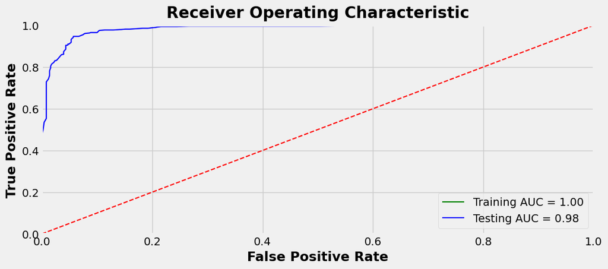

```
==========================================================================================

AdaBoostClassifier()
New X Shape is  (5000, 16)
Selected Features are :  ['Day_Mins' 'Night_Charge' 'Night_Calls' 'Eve_Charge' 'Day_Charge'
 'Eve_Mins' 'Eve_Calls' 'VMail_Message' 'Intl_Charge' 'Night_Mins'
 'CustServ_Calls' 'Intl_Calls' 'Intl_Mins' 'Day_Calls' 'NE' 'VT']
```

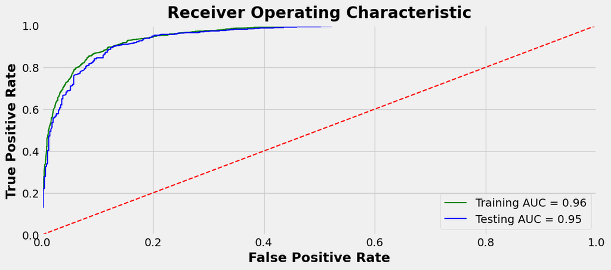

```
==========================================================================================

SGDClassifier(loss='modified_huber')
New X Shape is  (5000, 12)
Selected Features are :  ['Day_Mins' 'Night_Charge' 'Eve_Charge' 'Day_Charge' 'Eve_Mins'
 'Eve_Calls' 'Intl_Charge' 'Night_Mins' 'CustServ_Calls' 'Intl_Calls'
 'Intl_Mins' 'Day_Calls']
```

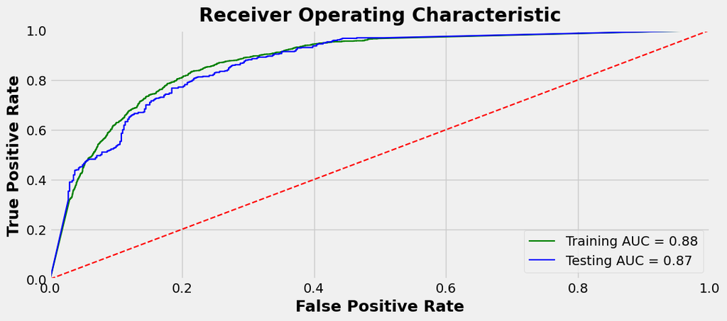

```
==========================================================================================

GradientBoostingClassifier()
New X Shape is  (5000, 12)
Selected Features are :  ['Day_Mins' 'Night_Charge' 'Night_Calls' 'Eve_Charge' 'Day_Charge'
 'Eve_Mins' 'VMail_Message' 'Intl_Charge' 'Night_Mins' 'CustServ_Calls'
 'Intl_Calls' 'Day_Calls']
```

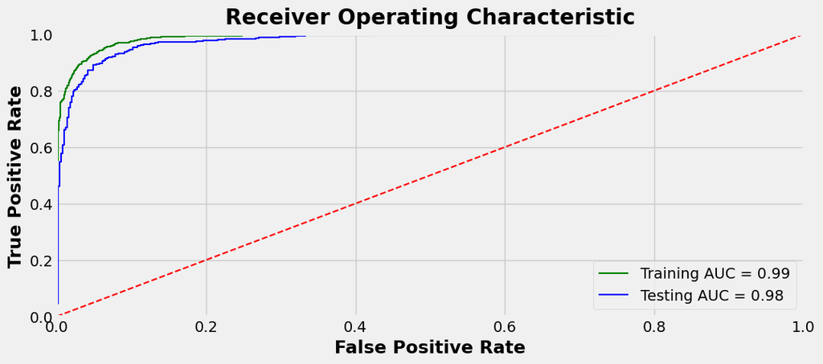

```
==========================================================================================

XGBClassifier(base_score=None, booster=None, callbacks=None,
              colsample_bylevel=None, colsample_bynode=None,
              colsample_bytree=None, early_stopping_rounds=None,
              enable_categorical=False, eval_metric=None, feature_types=None,
              gamma=None, gpu_id=None, grow_policy=None, importance_type=None,
              interaction_constraints=None, learning_rate=None, max_bin=None,
              max_cat_threshold=None, max_cat_to_onehot=None,
              max_delta_step=None, max_depth=None, max_leaves=None,
              min_child_weight=None, missing=nan, monotone_constraints=None,
              n_estimators=100, n_jobs=None, num_parallel_tree=None,
              predictor=None, random_state=None, ...)
New X Shape is  (5000, 15)
Selected Features are :  ['Day_Mins' 'Night_Charge' 'Night_Calls' 'Eve_Charge' 'Day_Charge'
 'Eve_Mins' 'VMail_Message' 'Intl_Charge' 'Night_Mins' 'CustServ_Calls'
 'Intl_Calls' 'Day_Calls' 'CT' 'GA' 'NE']
```

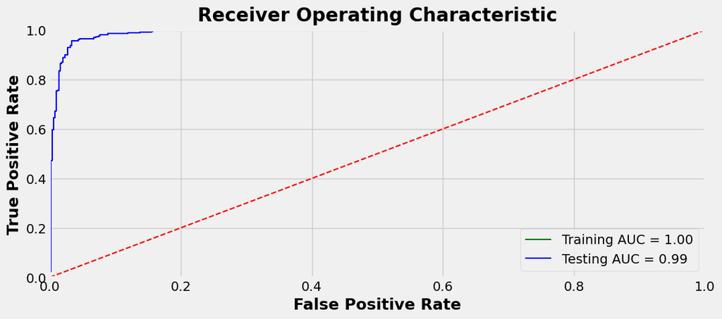

```
==========================================================================================

XGBRFClassifier(base_score=None, booster=None, callbacks=None,
                colsample_bylevel=None, colsample_bytree=None,
                early_stopping_rounds=None, enable_categorical=False,
                eval_metric=None, feature_types=None, gamma=None, gpu_id=None,
                grow_policy=None, importance_type=None,
                interaction_constraints=None, max_bin=None,
                max_cat_threshold=None, max_cat_to_onehot=None,
                max_delta_step=None, max_depth=None, max_leaves=None,
                min_child_weight=None, missing=nan, monotone_constraints=None,
                n_estimators=100, n_jobs=None, num_parallel_tree=None,
                objective='binary:logistic', predictor=None, random_state=None,
                reg_alpha=None, ...)
New X Shape is  (5000, 12)
Selected Features are :  ['Day_Mins' 'Night_Charge' 'Night_Calls' 'Eve_Charge' 'Day_Charge'
 'Eve_Mins' 'VMail_Message' 'Intl_Charge' 'Night_Mins' 'CustServ_Calls'
 'Intl_Calls' 'Day_Calls']
```

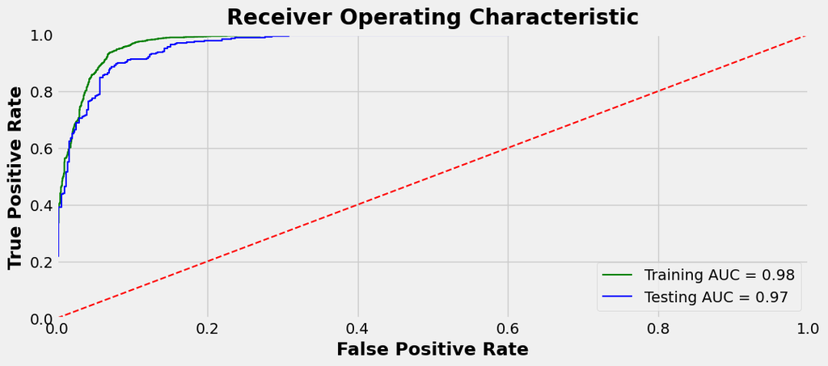

*Let's choose XGBClassifier and grid search to optimize it as it has the highest testing AUC=99%*

- We can drop State dummies as they did not show any imporovements.

```
    Dropping VMail_Plan which has a high correlation with ['VMail_Message']
```

### Train XGBClassifier

```
XGBFClassifierModel Train Score is :  0.8882962962962963
XGBFClassifierModel Test Score is :  0.8712
F1 Score Is:  0.874902874902875
```

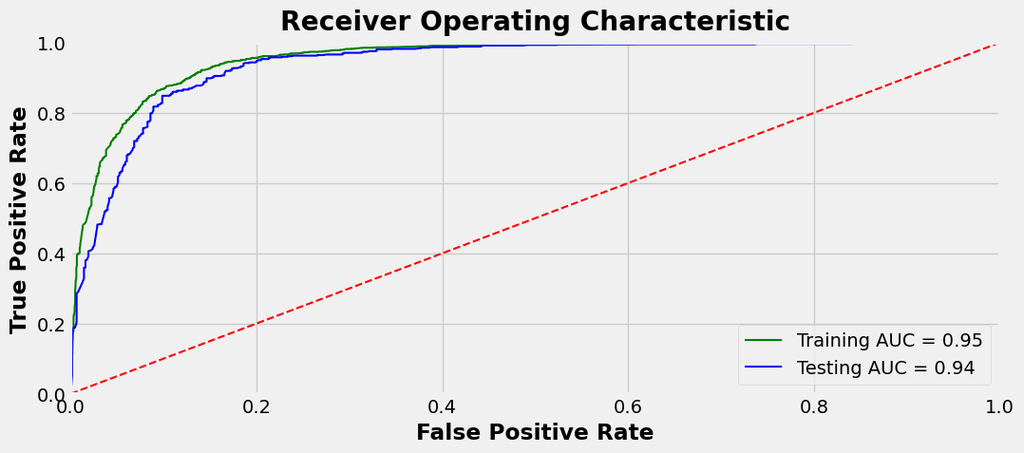

```
Confusion Matrix is :
 [[526 103]
 [ 58 563]]
```

```
Classification Report is :               precision    recall  f1-score   support

       False       0.90      0.84      0.87       629
        True       0.85      0.91      0.87       621

    accuracy                           0.87      1250
   macro avg       0.87      0.87      0.87      1250
weighted avg       0.87      0.87      0.87      1250
```

# Concolusion:

- *With Just four Features ['Day_Mins', 'Eve_Mins', 'Night_Calls', 'Night_Charge'] and XGBClassifier We Obtained a Model that predict Churn target with AUC 94% and we can increase it if we added more features but with the cost of complexity.*